# BIOSTAT M280 HW5 Solution Sketch

Dr. Hua Zhou

Mar 1, 2016

# Q3

We write a function `ddirmult` for evaluating the (log) density of Dirichlet-multinomial. When allowing zero parameter values, we have to be careful dealing with two special cases (1) $x_{ij} = \alpha_{ij} = 0$ and (2) $|\boldsymbol{\alpha}| = 0$.

```r
# clean workspace
rm(list = ls())

#' Density of Dirichlet-multinomial
#'
#' \code{ddirmult} evaluates the Dirichlet-multinomial density
#'
#' @param x an n-by-d matrix of counts
#' @param alpha an n-by-d or n-by-1 matrix of parameters
#' @param log log-density (TRUE) or density (FALSE)
#' @return an n vector of (log)-densities
#' @seealso
ddirmult <- function(x, alpha, log = FALSE) {

  # check x is count data
  if (any(x < 0))
    stop("Error: x should be nonnegative count data")
  # check positivity of alpha
  if (any(alpha < 0))
    stop("Error: Dirichlet-multinomial parameter alpha should be nonnegative")

  # check dimensions of input arguments
  if (is.vector(alpha) && length(alpha) > 1) {
    if (is.vector(x) && length(x) > 1) {
      if (length(x) != length(alpha)) {
        stop("Error: sizes of x and alpha do not match.")
        } else {
          # expand x to a matrix of matching size with alpha
          x <- matrix(x, 1, length(x))
          }
      } else if (is.vector(x) && length(x) <= 1) {
        stop("Error: x can not be a scalar")
        }
    # expand alpha to a matrix of matching size with x
    alpha <- matrix(alpha, nrow = nrow(x), ncol = length(alpha), byrow = TRUE)
    }
  if (any(dim(alpha) != dim(x)))
    stop("Error: dimensions of alpha and x do not match")

  # compute log-densities
  alphaRowSums <- rowSums(alpha)
  xRowSums <- rowSums(x)
  # lgamma(0 + 0) - lgamma(0) will produce NaNs.
  # This fixes x_{ij} = alpha_{ij} = 0 cases.
  # Is there better way to deal with this?
  alpha[(x == 0) & (alpha == 0)] <- 1
  # assemble log-likelihood
  # lgamma(0) throws a lot of warnings but they are valid
  logl <- suppressWarnings(
    lfactorial(xRowSums) + rowSums(lgamma(x + alpha)) +
      lgamma(alphaRowSums) - (rowSums(lfactorial(x)) +
      rowSums(lgamma(alpha)) + lgamma(alphaRowSums + xRowSums))
    )
  # Deal with alphaRowSums == 0 cases
  # fix the lgamma(0 + 0) - lgamma(0) produces NaN here
  logl[(xRowSums == 0) & (alphaRowSums == 0)] <- 0
  logl[(xRowSums > 0) & (alphaRowSums == 0)] <- - Inf

  # output
  if (log)
    return(logl)
  else
    return(exp(logl))
  }
```

We read in handwritten digit training data and evaluate the log-likelihood of all digits at $\alpha = (1, \ldots, 1)$.

```r
traindata <-
  read.table("http://hua-zhou.github.io/teaching/biostatm280-2016winter/optdigits.tra",
             sep = ",")
traindata <- as.matrix(traindata)
# evaluate the log-likelihood of all training digits
ptm <- proc.time()
sum(ddirmult(traindata[, -65], rep(1, 64), log = TRUE))
```

```
## [1] -638818
```

```r
proc.time() - ptm
```

```
##    user  system elapsed
##   0.153   0.005   0.157
```

# Q5

The score $\nabla L(\boldsymbol{\alpha})$ has entry  
$\begin{eqnarray*} \frac{\partial}{\partial \alpha_j} L(\boldsymbol{\alpha}) &=& \sum_{i=1}^n [\psi(x_{ij}+\alpha_j) - \psi(\alpha_j)] - \sum_{i=1}^n [\psi(|\boldsymbol{x}_i|+|\boldsymbol{\alpha}|) - \psi(|\boldsymbol{\alpha}|)], \end{eqnarray*}$  
where $\psi(x) = [\ln \Gamma(x)]' = \Gamma'(x)/\Gamma(x)$ is the digamma function. The observed information matrix is  
$\begin{eqnarray*} - d^2 L(\boldsymbol{\alpha}) = \boldsymbol{D} - c \boldsymbol{1}_d \boldsymbol{1}_d^T, \end{eqnarray*}$  
where $\boldsymbol{D}$ is a diagonal matrix with $j$-th diagonal entry  
$\begin{eqnarray*} d_j = \sum_{i=1}^n [\psi'(\alpha_j) -\psi'(x_{ij}+\alpha_j)] = \sum_{i=1}^n \sum_{k=0}^{x_{ij}-1} \frac{1}{(\alpha_j + k)^2}. \end{eqnarray*}$ and $\begin{eqnarray*} c = \sum_{i=1}^n [ \psi'(|\boldsymbol{\alpha}|) - \psi'(|\boldsymbol{x}_i|+|\boldsymbol{\alpha}|)] = \sum_{i=1}^n \sum_{k=0}^{|\boldsymbol{x}_i|-1} \frac{1}{(|\boldsymbol{\alpha}|+k)^2}. \end{eqnarray*}$ The expected information matrix is $\begin{eqnarray*} \mathbf{E}[-d^2L(\boldsymbol{\alpha})] = \mathbf{E}(\boldsymbol{D}) - c \boldsymbol{1}_d \boldsymbol{1}_d^T \end{eqnarray*}$ with entries $d_j$ replaced by its expectation $\begin{eqnarray*} \mathbf{E}(d_j) &=& \sum_{i=1}^n \sum_{k=0}^{|\boldsymbol{x}_i|-1} \frac{\mathbf{P}(X_{ij}>k)}{(\alpha_j+k)^2}, \end{eqnarray*}$ where $X_{ij}$ is a beta-binomial random variable with batch size $|\boldsymbol{x}_i|$ and parameter $(\alpha_j, |\boldsymbol{\alpha}|-\alpha_j)$.

# Q6

To calculate the expected information matrix, we need to evaluate numerous beta-binomial tail probabilities :( Let’s go back exploring the Newton’s algorithm.

# Q7

It is clear that $d_j,c>0$, whenever all columns sums of data are nonzero. The observed information matrix $-d^2L(\boldsymbol{\alpha})$ is a diagonal matrix plus a rank one update. By the Sherman-Morrison formula (HW2 Q3(a)) and the determinant formula (HW2 Q3(d)), $\begin{eqnarray*} [-d^2L(\boldsymbol{\alpha})]^{-1} &=& \boldsymbol{D}^{-1} + \frac{1}{c^{-1} - \sum_j d_j^{-1}} \boldsymbol{D}^{-1} \boldsymbol{1} \boldsymbol{1}^T \boldsymbol{D}^{-1} \\ \text{det}[-d^2L(\boldsymbol{\alpha})] &=& \left( \prod_j d_j \right) \left(1 - c \sum_j d_j^{-1} \right), \end{eqnarray*}$ which make it clear that the observed information matrix $-d^2L(\boldsymbol{\alpha})$ is pd if and only if $c < \left( \sum_j d_j^{-1} \right)^{-1}.$ This fact suggests a remedy when the observed information matrix is not positive definite: we simply shrink $c$ to be less than $(\sum_j d_j^{-1})^{-1}$ if necessary. Again thanks to the Sherman-Morrison formula (HW2 Q3(a)), the Newton direction can be computed in $O(d)$ flops $\begin{eqnarray*} [- d^2 L(\boldsymbol{\alpha}^{(t)})]^{-1} \nabla L(\boldsymbol{\alpha}^{(t)}) &=& \boldsymbol{D}^{-1} \nabla L(\boldsymbol{\alpha}^{(t)}) + \frac{1}{\tilde c^{-1} - \sum_j d_j^{-1}} \boldsymbol{D}^{-1} \boldsymbol{1} \boldsymbol{1}^T \boldsymbol{D}^{-1} \nabla L(\boldsymbol{\alpha}^{(t)}). \end{eqnarray*}$ Here $\tilde c = c$ if $c<(\sum_j d_j^{-1})^{-1}$ or say $0.95 (\sum_j d_j^{-1})^{-1}$ otherwise. Note we only need to store the vector of $d_j$. **There is no need to store the whole information matrix.**

Here is an interesting question. We know expected information matrix is positive semidefinite. This implies that $c \le [\sum_j (\mathbf{E}(d_j))^{-1}]^{-1}$, i.e., $\begin{eqnarray*} \left( \sum_{i=1}^n \sum_{k=0}^{|\boldsymbol{x}_i|-1} \frac{1}{|\boldsymbol{\alpha}|+k} \right) \left( \sum_{j=1}^d \left( \sum_{i=1}^n \sum_{k=0}^{|\boldsymbol{x}_i|-1} \frac{\mathbf{P}(X_{ij}>k)}{(\alpha_j+k)^2} \right)^{-1} \right) \le 1. \end{eqnarray*}$ Is there any way to show this inequality probabilistically?

# Q8

Let us derive a method of moment estimator. If $\boldsymbol{P} = (P_1,\ldots,P_d)$ is from Dirichlet with parameter $\boldsymbol{\alpha}$, then $\begin{eqnarray*} \mathbf{E}(P_j) = \frac{\alpha_j}{|\boldsymbol{\alpha}|}, \quad \mathbf{E}(P_j^2) = \frac{\alpha_j(\alpha_j+1)}{|\boldsymbol{\alpha}|(|\boldsymbol{\alpha}|+1)}. \end{eqnarray*}$ Therefore $\begin{eqnarray*} \sum_j \frac{\mathbf{E}(P_j^2)}{\mathbf{E}(P_j)} = \frac{|\boldsymbol{\alpha}|+d}{|\boldsymbol{\alpha}|+1}. \end{eqnarray*}$ We estimate the left hand side by $\begin{eqnarray*} \hat \rho = \sum_j \frac{\sum_i (x_{ij}/|\boldsymbol{x}_i|)^2}{\sum_i (x_{ij}/|\boldsymbol{x}_i|)} \end{eqnarray*}$ and solve for $|\boldsymbol{\alpha}^{(0)}| = (d-\hat \rho)/(\hat \rho - 1)$. Then we initialize $\begin{eqnarray*} \alpha_j^{(0)} = |\boldsymbol{\alpha}^{(0)}| \frac{\sum_i x_{ij}}{\sum_i |\boldsymbol{x}_i|} = \left( \frac{d-\hat \rho}{\hat \rho - 1} \right) \left( \frac{\sum_i x_{ij}}{\sum_i |\boldsymbol{x}_i|} \right). \end{eqnarray*}$

# Q9

Here is my implementation of the Newton-Raphson method for finding MLE.

```r
#' MLE of Dirichlet-multinomial distribution by Newton's method
#'
#' \code{dirmultfit} finds the MLE of Dirichlet-multinomial by Newton method
#'
#' @param X an n-by-d matrix of counts
#' @param weights an n vector of observation weights
#' @param alpha0 an n vector of starting point
#' @param tolfun convergence tolerance in log-likelihood values
#' @param maxiters maximum number of iterations
#' @param display verbose mode (TRUE) or not (FALSE)
#' @return a list that contains
#'  alphaHat MLE
#'  se standard error of MLE
#'  maximum log-likelihood at MLE
#'  iterations number of iterations performed
#'  gradient gradient at MLE
#'  obsinfo observed information at MLE
#'  obsinfoInv inverse of observed information at MLE
#' @seealso
dirmultfit <- function(X, weights = NULL, alpha0 = NULL,
                       tolfun = 1e-6, maxiters = 100, display = FALSE) {

  # check observation weights
  if (!is.null(weights)) {
    weights <- weight[rowSums(X) != 0]
    if (any(weights < 0))
      stop("Error: observation weigths should be positive")
    }

  # remove data points with batch size 0
  rsum <- rowSums(X)
  if (any(rsum == 0)) {
    rmv <- sum(rsum == 0)
    message(paste( "Warning: ", rmv,
                   " rows are removed because the row sums are 0"))
    }

  # remove the bins with no observations
  csum <- colSums(X)
  if (any(csum == 0)) {
    rmv <- sum(csum == 0)
    message(paste("Warning: ", rmv,
                  " columns are removed because the column sums are 0"))
    }

  # cleaned up data
  data <- X[rsum != 0, csum != 0]
  N <- nrow(data)       ## Sample size
  d <- ncol(data)           ## Number of parameters
  m <- rowSums(data)  ## batch sizes

  # set default obs weights to be all 1s
  if (is.null(weights))
    weights <- rep(1, N)
  weightsum = sum(weights)

  # set starting points
  if (is.null(alpha0)) {
    # method of moment estimate
    rho <- sum(colSums(weights * (data / m)^2) / (colSums(weights * data / m)))
    alpha0 <- as.vector(colSums(weights * data / m) * (d - rho) / (rho - 1) / N)
    alpha0[alpha0 <= 0] = 1e-6
    } else {
      alpha0 <- alpha0[csum != 0]
      if (!is.vector(alpha0) && length(alpha0) != d) {
        stop("Error: dimension of alpha0 does not match data")
        } else if (any(alpha0 <= 0)) {
          # user provided starting values
          stop("Error: starting values should be positive")
          }
      }

  # prepare some variables before looping
  alphaHat <- alpha0
  alphaSum <- sum(alphaHat)
  loglIter <- sum(weights * ddirmult(data, alpha0, log = TRUE))

  # Print initial log-like if asked.
  if (display)
    print(paste("iteration ", 1, ", logL = ", loglIter, sep=""))

  # backtrack max iterations
  backtrackMaxiters <- 10

  ##----------------------------------------##
  ## The Newton loop
  if (maxiters == 1) iter <- 1
  else {
    for (iter in 2:maxiters) {

      # score vector
      alphaMat <- matrix(alphaHat, nrow = N, ncol = d, byrow = TRUE)
      score <- colSums(weights * digamma(data + alphaMat)) -
        weightsum * (digamma(alphaHat) - digamma(alphaSum)) -
        sum(weights * digamma(alphaSum + m))
      # observed info. matrix = diag(obsinfoDvec) - obsinfoC
      obsinfoDvec <- weightsum * trigamma(alphaHat) -
        colSums(weights * trigamma(data + alphaMat))
      obsinfoDvecInv <- 1 / obsinfoDvec
      obsinfoC <- weightsum * trigamma(alphaSum) -
        sum(weights * trigamma(m + alphaSum))
      # shrink c if necessary to make obs. info. pos def
      if (obsinfoC * sum(obsinfoDvecInv) >= 1) {
        if (display) print("shrink c")
        obsinfoC <- 0.95 / sum(obsinfoDvecInv)
        }

      # compute Newton direction
      newtondir <- obsinfoDvecInv * score
      newtondir <- newtondir +
        (sum(newtondir) / (1 / obsinfoC - sum(obsinfoDvecInv))) * obsinfoDvecInv

      # line search by step halving
      if (any(newtondir < 0)) {
        # make sure Newton iterate always lands within boundary
        stepsize <- min(- alphaHat[newtondir < 0] / newtondir[newtondir < 0])
        stepsize <- min(0.95 * stepsize, 1)
        } else {
          stepsize <- 1
        }
      for (btiter in 1:backtrackMaxiters) {
        alphaNew <- alphaHat + stepsize * newtondir
        loglNew <- sum(weights * ddirmult(data, alphaNew, log = TRUE))
        # line search successful if improving log-L
        if (loglNew > loglIter) break
        else if (btiter == backtrackMaxiters) {
          warning("line search failed")
        } else {
          if (display) print("step halving")
          stepsize <- stepsize / 2
          }
        }
      alphaHat <- alphaNew
      alphaSum <- sum(alphaHat)
      loglOld <- loglIter
      loglIter <- loglNew

      # Print the iterate log-like if requested
      if (display)
        print(paste("iteration ", iter, ", logL = ", loglIter, sep=""))

      # check convergence criterion
      if (abs(loglIter - loglOld) < tolfun * (abs(loglOld) + 1)) break
      }
    }
  ##----------------------------------------##
  ## End of Newton loop

  # score, i.e., gradient
  alphaMat <- matrix(alphaHat, nrow = N, ncol = d, byrow = TRUE)
  score <-
    colSums(weights * digamma(data + alphaMat)) -
    weightsum * (digamma(alphaHat) - digamma(alphaSum)) -
    sum(weights * digamma(alphaSum + m))
  # diagonal part of the observed information matrix
  obsinfoDvec <- weightsum * trigamma(alphaHat) -
    colSums(weights * trigamma(data + alphaMat))
  obsinfoDvecInv <- 1 / obsinfoDvec
  # the constant c in the observed information matrix
  obsinfoC <- weightsum * trigamma(alphaSum) -
    sum(weights * trigamma(m + alphaSum))
  # compute standard errors
  obsinfo <- diag(obsinfoDvec) - obsinfoC
  obsinfoInv <- diag(obsinfoDvecInv) +
    outer(obsinfoDvecInv, obsinfoDvecInv) / (1 / obsinfoC - sum(obsinfoDvecInv))
  se <- sqrt(diag(obsinfoInv))

  # restore to original data size
  if (any(csum == 0)) {
    colidx <- (csum != 0)
    # parameter estimate
    tmp <- alphaHat
    alphaHat <- rep(0, ncol(X))
    alphaHat[colidx] <- tmp
    # gradient/score vector
    tmp <- score
    score <- rep(0, ncol(X))
    score[colidx] <- tmp
    score[!colidx] <- weightsum * digamma(alphaSum) -
      sum(weights * digamma(alphaSum + m))
    # obs info matrix
    tmp <- obsinfo
    obsinfo <- matrix(0, ncol(X), ncol(X))
    obsinfo[colidx, colidx] <- tmp
    obsinfo[!colidx, ] <- - obsinfoC
    obsinfo[, !colidx] <- - obsinfoC
    # inverse of obs info matrix
    tmp <- obsinfoInv
    obsinfoInv <- matrix(0, ncol(X), ncol(X))
    obsinfoInv[colidx, colidx] <- tmp
    }

  # output
  list(estimate = alphaHat, se = se, maximum = loglIter, iterations = iter,
       gradient = score, obsinfo = obsinfo, obsinfoInv = obsinfoInv)
  }
```

Now we determine the MLE for each digit under the Dirichlet-multinomial and multinomial models respectively.

```r
# pre-allocate variables
alphahat <- matrix(0, nrow = 10, ncol = 64)
phat <- matrix(0, nrow = 10, ncol = 64)
loglmn <- rep(0, 10)
logldirmn <- rep(0, 10)
digitCount <- rep(0, 10)
iters <- rep(0, 10)
runtime <- rep(0, 10)
# loop over digit
for (dig in 0:9) {
  # MLE for Dirichlet-multinomial
  digitdata <- traindata[traindata[, 65] == dig, -65]
  digitCount[dig + 1] <- nrow(digitdata)
  ptm <- proc.time() # start timing
  digMLE <- dirmultfit(digitdata, tolfun = 1e-8, display = TRUE)
  #digMLE <- dirmultfit(digitdata, alpha0 = matrix(1, 1, ncol(traindata) - 1), tolfun = 1e-8, display = TRUE)
  runtime[dig + 1] <- (proc.time() - ptm)[3] # stop timing
  #print(digMLE$gradient) # print gradient
  alphahat[dig + 1, ] <- digMLE$estimate
  iters[dig + 1] <- digMLE$iterations
  logldirmn[dig + 1] <- digMLE$maximum
  # MLE and log-likelihood for multinomial
  phat[dig + 1, ] <- colSums(digitdata) / sum(digitdata)
  cidx <- (colSums(digitdata) != 0)
  loglmn[dig + 1] <- sum(lgamma(rowSums(digitdata[, cidx]) + 1)) -
    sum(lgamma(digitdata[, cidx] + 1)) +
    sum(colSums(digitdata[, cidx]) * log(phat[dig + 1, cidx]))
  }
```

```
## [1] "iteration 1, logL = -38197.2101571317"
## [1] "iteration 2, logL = -37626.8316212697"
## [1] "iteration 3, logL = -37416.9630075463"
## [1] "iteration 4, logL = -37364.3217419136"
## [1] "iteration 5, logL = -37358.5357607676"
## [1] "iteration 6, logL = -37358.4201286343"
## [1] "iteration 7, logL = -37358.4200651812"
```

```
## [1] "iteration 1, logL = -42393.2753225462"
## [1] "iteration 2, logL = -42247.3790833947"
## [1] "iteration 3, logL = -42192.892511791"
## [1] "iteration 4, logL = -42183.8711723513"
## [1] "iteration 5, logL = -42180.1409236255"
## [1] "iteration 6, logL = -42179.2934904956"
## [1] "iteration 7, logL = -42179.2456000791"
## [1] "iteration 8, logL = -42179.2454225598"
```

```
## [1] "iteration 1, logL = -40274.084161804"
## [1] "iteration 2, logL = -40032.0377685787"
## [1] "iteration 3, logL = -39992.7406820426"
## [1] "iteration 4, logL = -39986.6465223509"
## [1] "iteration 5, logL = -39985.368264586"
## [1] "iteration 6, logL = -39985.2651593761"
## [1] "iteration 7, logL = -39985.2643117435"
## [1] "iteration 8, logL = -39985.2643116789"
```

```
## [1] "iteration 1, logL = -40825.3731951663"
## [1] "iteration 2, logL = -40559.6038767491"
## [1] "iteration 3, logL = -40521.2911319022"
## [1] "iteration 4, logL = -40519.4774633384"
## [1] "iteration 5, logL = -40519.4708914076"
## [1] "iteration 6, logL = -40519.4708911796"
```

```
## [1] "iteration 1, logL = -43771.7776546535"
## [1] "iteration 2, logL = -43529.9141084289"
## [1] "iteration 3, logL = -43491.7572999275"
## [1] "iteration 4, logL = -43489.1158814316"
## [1] "iteration 5, logL = -43488.8548822617"
## [1] "iteration 6, logL = -43488.7814817402"
## [1] "iteration 7, logL = -43488.7732577865"
## [1] "iteration 8, logL = -43488.7731396411"
```

```
## [1] "iteration 1, logL = -41454.0653055455"
## [1] "iteration 2, logL = -41387.280072851"
## [1] "iteration 3, logL = -41292.6536675442"
## [1] "iteration 4, logL = -41237.3987107637"
## [1] "iteration 5, logL = -41204.8643468187"
## [1] "iteration 6, logL = -41192.9533244173"
## [1] "iteration 7, logL = -41191.3415818718"
## [1] "iteration 8, logL = -41191.3093395944"
## [1] "iteration 9, logL = -41191.3093251929"
```

```
## [1] "iteration 1, logL = -37917.8875216149"
## [1] "iteration 2, logL = -37727.4078877034"
## [1] "iteration 3, logL = -37703.5570621692"
## [1] "iteration 4, logL = -37702.5348476369"
## [1] "iteration 5, logL = -37702.5102296827"
## [1] "iteration 6, logL = -37702.5098024294"
## [1] "iteration 7, logL = -37702.5098022516"
```

```
## [1] "iteration 1, logL = -40576.3876660246"
## [1] "iteration 2, logL = -40401.8207448634"
## [1] "iteration 3, logL = -40312.0655349939"
## [1] "iteration 4, logL = -40305.495643462"
## [1] "iteration 5, logL = -40304.333996472"
## [1] "iteration 6, logL = -40304.0223596794"
## [1] "iteration 7, logL = -40303.9970821083"
## [1] "iteration 8, logL = -40303.9968897847"
```

```
## [1] "iteration 1, logL = -43304.8870184651"
## [1] "iteration 2, logL = -43146.6753908556"
## [1] "iteration 3, logL = -43132.086334199"
## [1] "iteration 4, logL = -43131.2988113079"
## [1] "iteration 5, logL = -43131.0009175591"
## [1] "iteration 6, logL = -43130.8725896412"
## [1] "iteration 7, logL = -43130.8481113513"
## [1] "iteration 8, logL = -43130.8471299011"
## [1] "iteration 9, logL = -43130.8471280759"
```

```
## [1] "iteration 1, logL = -43988.6533780859"
## [1] "step halving"
## [1] "iteration 2, logL = -43749.4038505245"
## [1] "iteration 3, logL = -43710.9081220285"
## [1] "iteration 4, logL = -43709.6705232057"
## [1] "iteration 5, logL = -43709.6536916466"
## [1] "iteration 6, logL = -43709.6536587313"
```

```r
# print(alphahat)
```

# Q11

Does Dirichlet-multinomial provide a better fit than multinomial? We see likelihood ratio test (LRT) p-values are essentially 0 for all digits. Therefore with one extra parameter, Dirichlet-multinomial offers a much better fit than multinomial.

```r
lrtstat <- 2 * (logldirmn - loglmn)
lrtpval <- pchisq(q = lrtstat, df = 1, lower.tail = FALSE, log.p = FALSE)
```

Some summary statistcis:

```r
library(knitr)
tabledata <- cbind(0:9, digitCount, loglmn, logldirmn, lrtpval, iters, runtime)
colnames(tabledata) <- c("Digit", "n", "logL MN", "logL Dir-MN", "LRT P Val",
                         "Iters", "Run Time")
kable(tabledata, format = "pandoc", caption = "Digit MLEs",
      digits = c(0, 0, 2, 2, 6, 0, 3), row.names = FALSE,
      align = c("l", "l", "l", "l", "l", "l", "l"))
```

Digit MLEs

| Digit | n | logL MN | logL Dir-MN | LRT P Val | Iters | Run Time |
| --- | --- | --- | --- | --- | --- | --- |
| 0 | 376 | -39592.20 | -37358.42 | 0 | 7 | 0.104 |
| 1 | 389 | -54039.23 | -42179.25 | 0 | 8 | 0.142 |
| 2 | 380 | -49111.45 | -39985.26 | 0 | 8 | 0.140 |
| 3 | 389 | -47089.08 | -40519.47 | 0 | 6 | 0.143 |
| 4 | 387 | -57344.08 | -43488.77 | 0 | 8 | 0.186 |
| 5 | 376 | -51713.00 | -41191.31 | 0 | 9 | 0.188 |
| 6 | 377 | -42597.30 | -37702.51 | 0 | 7 | 0.120 |
| 7 | 387 | -49472.98 | -40304.00 | 0 | 8 | 0.144 |
| 8 | 380 | -49695.85 | -43130.85 | 0 | 9 | 0.165 |
| 9 | 382 | -54577.79 | -43709.65 | 0 | 6 | 0.130 |

# Q12

Finally we come to the classificaion part.

```r
# read in the test set of 1797 digits
testdata <-
  read.table("http://hua-zhou.github.io/teaching/biostatm280-2016winter/optdigits.tes",
             sep = ",")
testdata <- as.matrix(testdata)
# testDigitProb stores posterior probability of each digit being 0,1,...,9
testDigitProb <- matrix(0, dim(testdata)[1], 10)
for (dig in 0:9) {
  testDigitProb[, dig + 1] <-
    ddirmult(testdata[, -65], alphahat[dig + 1, ], log = TRUE)
  }
testDigitProb <- testDigitProb +
  rep(log(digitCount / sum(digitCount)), each = nrow(testdata))
digitPred <- max.col(testDigitProb) - 1
```

Confusion table and total error rate summarize the classification results. Digits {1,2,8,9} and {5,9} seem to be easily mis-classified.

```r
# construct confusion table
table(testdata[, 65], digitPred)
```

```
##    digitPred
##       0   1   2   3   4   5   6   7   8   9
##   0 174   0   0   0   4   0   0   0   0   0
##   1   0 132  21   0   2   0   2   0  14  11
##   2   0   9 151   2   0   1   1   1   8   4
##   3   0   2   1 154   0   4   0   7   5  10
##   4   0   2   0   0 173   0   1   2   2   1
##   5   0   0   0   0   1 166   1   0   0  14
##   6   0   6   0   0   2   1 170   0   2   0
##   7   0   0   0   0  11   0   0 164   2   2
##   8   0  22   1   0   1   1   1   1 134  13
##   9   0   5   0   4   6   2   0   3   4 156
```

```r
# overall error rate
sum(testdata[, 65] != digitPred) / length(digitPred)
```

```
## [1] 0.1240957
```

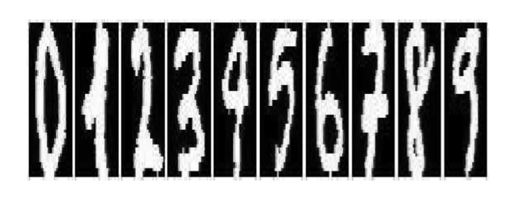

# Comparison to `optim` routine in R

Let’s try a “black-box” optimizer `optim` in `R`. We see in many cases `optim` outputs an *inferior solution* using 10 fold more run time. Keep in mind the `optim` function is implemented in Fortran. Message: *Taking advantage of problem structure beats black-box optimizer.*

```r
# functions for evaluating objective values and gradient
objfun <- function(alpha, x) {
  - sum(ddirmult(x, alpha, log = TRUE))
  }
objfun.grad <- function(alpha, x) {
  alphaSum <- sum(alpha)
  alphaMat <- matrix(alpha, nrow = nrow(x), ncol = ncol(x), byrow = TRUE)
  grad <- - (colSums(digamma(x + alphaMat)) -
               nrow(x) * (digamma(alpha) - digamma(alphaSum)) -
               sum(digamma(alphaSum + rowSums(x))))
}
# pre-allocate variables
loglOptim <- rep(0, 10)
itersOptim <- rep(0, 10)
runtimeOptim <- rep(0, 10)
# loop over digit
for (dig in 0:9) {
  # MLE for Dirichlet-multinomial
  digitdata <- traindata[traindata[, 65] == dig, -65]
  cidx <- (colSums(digitdata) != 0)
  # use the same MoM start point for a fair comparison
  alpha0 <- dirmultfit(digitdata[, cidx], maxiters = 1)$estimate
  ptm <- proc.time() # start timing
  optimres <- optim(alpha0, fn = objfun, gr = objfun.grad,
                    digitdata[, cidx], method = "L-BFGS-B", lower = 1e-16,
                    upper = Inf)
  runtimeOptim[dig + 1] <- (proc.time() - ptm)[3] # stop timing
  loglOptim[dig + 1] <- - optimres$value
  itersOptim[dig + 1] <- optimres$counts[2]
  }
# display summaries in table
tabledata <- cbind(0:9, logldirmn, loglOptim, iters, itersOptim,
                   runtime, runtimeOptim)
colnames(tabledata) <- c("Digit", "logL dirmultfit", "logL optim",
                         "Iters dirmultfit", "Iters optim",
                         "Runtime dirmultfit", "Runtime optim")
kable(tabledata, format = "pandoc", caption = "dirmultfit vs optim",
      digits = c(0, 2, 2, 2, 2, 2, 2), row.names = FALSE,
      align = c("l", "l", "l", "l", "l", "l", "l"))
```

dirmultfit vs optim

| Digit | logL dirmultfit | logL optim | Iters dirmultfit | Iters optim | Runtime dirmultfit | Runtime optim |
| --- | --- | --- | --- | --- | --- | --- |
| 0 | -37358.42 | -37403.72 | 7 | 119 | 0.10 | 1.25 |
| 1 | -42179.25 | -42179.28 | 8 | 115 | 0.14 | 1.29 |
| 2 | -39985.26 | -40019.18 | 8 | 137 | 0.14 | 1.66 |
| 3 | -40519.47 | -40601.22 | 6 | 130 | 0.14 | 1.60 |
| 4 | -43488.77 | -43492.24 | 8 | 137 | 0.19 | 1.84 |
| 5 | -41191.31 | -41193.51 | 9 | 121 | 0.19 | 1.51 |
| 6 | -37702.51 | -37765.91 | 7 | 126 | 0.12 | 1.41 |
| 7 | -40304.00 | -40328.87 | 8 | 134 | 0.14 | 1.55 |
| 8 | -43130.85 | -43172.08 | 9 | 130 | 0.17 | 1.45 |
| 9 | -43709.65 | -43710.04 | 6 | 125 | 0.13 | 1.57 |

Display system information and clean up.